# LEC 2

Maria Retamal Fuentes, Teodoro Hochfärber Salinas

18 de noviembre de 2018

# Nota

Se utilizo Python3 para el uso de este laboratorio.

## Pregunta 1

- Si en el primer turno el jugador saca 5 cartas de la baraja (sin reemplazo) ¿Cual es la probabilidad de que su mano sea no consistente?

```r
magia <- rep("magia", 10)
monstruo <- rep("monstruo", 20)
trampa <- rep("trampa", 10)

baraja <- c(monstruo, magia, trampa)
casosFavorables <- 0

for(i in 1:500){
  mano <- sample(baraja, size = 5)
  a <- "trampa" %in% mano
  b <- "monstruo" %in% mano
  c <- "magia" %in% mano

  if(a & b & c){
    casosFavorables <- casosFavorables + 1
  }
}

probnofav<- 1 - casosFavorables / 500
```

Por lo tanto la probabilidad de que su mano no sea consistente es:

```r
probnofav
```

```
## [1] 0.386
```

- Si ahora consideramos que el jugador roba (sacar sin reemplazo) una carta en su primer turno, ¿Cual es la nueva probabilidad de que la mano no sea consistente?

```r
magia <- rep("magia", 10)
monstruo <- rep("monstruo", 20)
trampa <- rep("trampa", 10)

baraja <- c(monstruo, magia, trampa)
casosFavorables <- 0

for(i in 1:500){
  mano <- sample(baraja, size = 6)
  a <- "trampa" %in% mano
  b <- "monstruo" %in% mano
  c <- "magia" %in% mano

  if(a & b & c){
    casosFavorables <- casosFavorables + 1
  }
}

nocons<-1 - casosFavorables / 500
```

Entonces la probabilidad de que la mano no sea consistente es:

```r
nocons
```

```
## [1] 0.294
```

- En el juego, el jugador obtiene una mano inicial de 5 cartas y además roba al comienzo de cada turno (incluyendo el primero) 1 carta extra. El jugador cree tener muchos monstruos en su baraja, por lo que cambia 5 de estos por trampas, con la idea de poder defenderse con estas trampas por los primeros 2 turnos hasta obtener un monstruo. ¿Cual es la probabilidad de que se cumpla esta estrategia del jugador? esto es, obtener 2 de estas trampas nuevas en la mano original o en los 2 robos consecutivos y luego obtener un monstruo en el tercer robo

```r
magia <- rep("magia", 10)
monstruo <- rep("monstruo", 20)
trampa <- rep("trampa", 10)
trampaN <- rep("trampanueva", 5)

barajaNueva <- c(monstruo, magia, trampa, trampaN)
casosFavorables <- 0

for(i in 1:500){
  mano <- sample(barajaNueva, size = 8)
  aux <- mano[1:7]

  a <- aux[aux == "trampanueva"]

  if(length(a) == 2 & mano[8] == "monstruo"){
    casosFavorables <- casosFavorables + 1
  }
}

prob3<- casosFavorables / 500
```

La probabilidad es:

```r
prob3
```

```
## [1] 0.068
```

- Si ahora consideramos una baraja mas compleja compuesta por 15 Monstruos debiles, 5 Monstruos fuertes, 5 Magias normales, 5 Magias de equipo, 3 Magias de campo, 5 Trampas normales y 2 ContraTrampas. ¿Cual es la probabilidad de obtener una mano (5 cartas) competitiva? considerar como no competitivo obtener en la primera mano: Monstruos fuertes, Magias de equipo o Trampas normales. Comente la dificultad de realizar este calculo de forma teorica.

```r
mn <- rep("magia normal", 5)
me <- rep("magia equipo", 5)
mc <- rep("magia campo", 3)
md <- rep("monstruo debil", 15)
mf <- rep("monstruo fuerte", 5)
trampa <- rep("trampa", 5)
contratrampa <- rep("contratrampa", 2)

baraja <- c(mn, me, mc, md, mf, contratrampa, trampa)
casosFavorables <- 0

for(i in 1:500){
  mano <- sample(baraja, size = 5)
  a <- "trampa" %in% mano
  b <- "monstruo fuerte" %in% mano
  c <- "magia equipo" %in% mano

  if(a || b || c){
    casosFavorables <- casosFavorables + 1
  }
}

prob4<-1 - casosFavorables / 500
```

La probabilidad es:

```r
prob4
```

```
## [1] 0.068
```

La dificultad de calcular la probabilidad en forma teorica esto en enumerar todos los casos posibles pues son muchas manos distintas.

## Pregunta 2

- Muestre como converge la probabilidad de obtener una carta de monstruo al aumentar el tama?o de las muestras con un grafico. ¿Converge al valor teorico?

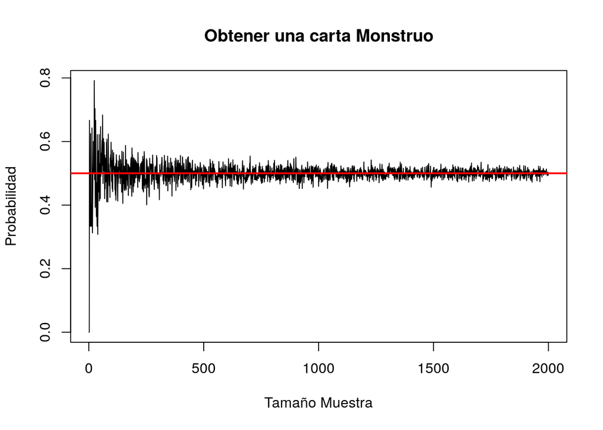

```r
magia <- rep("magia", 10)
monstruo <- rep("monstruo", 20)
trampa <- rep("trampa", 10)

baraja <- c(monstruo, magia, trampa)
converg <- c()
for(i in 1:2000){
  casosFavorables <- 0
  for (j in seq(1,i)){
    mano <- sample(baraja, size = 1)

    if("monstruo" %in% mano){
      casosFavorables <- casosFavorables + 1
    }
  }
  probabilidad = casosFavorables / j
  converg <- c(converg, probabilidad)
}

plot(1:2000,converg,
     xlab = "Tamaño Muestra",
     ylab = "Probabilidad",
     main = "Obtener una carta Monstruo", type='l')
abline(h=20/40,col="red",lwd=2)
```

- Muestre como converge la probabilidad de obtener una mano inicial (5 cartas) con 5 monstruos. Muestre en el gráfico el valor teórico de esta situación. ¿Es correcta la convergencia mostrada en el gráfico?

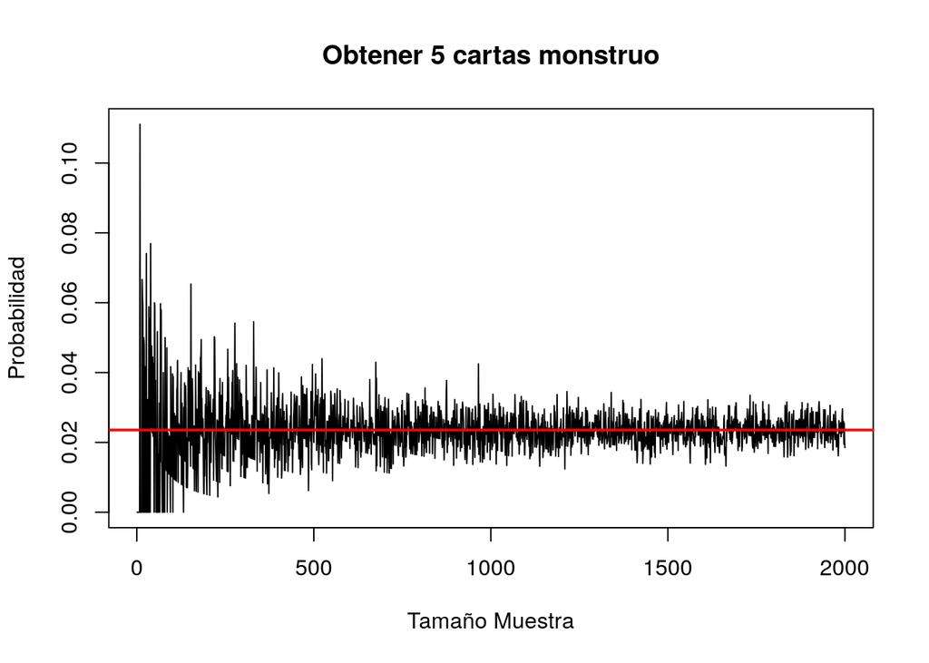

```r
magia <- rep("magia", 10)
monstruo <- rep("monstruo", 20)
trampa <- rep("trampa", 10)

baraja <- c(monstruo, magia, trampa)
converg <- c()
for(i in 1:2000){
  casosFavorables <- 0
  for (j in seq(1,i)){
    mano <- sample(baraja, size = 5)
    aux <- mano[1:5]

    a <- aux[aux == "monstruo"]

    if(length(a)==5){
      casosFavorables <- casosFavorables + 1
    }
  }
  probabilidad = casosFavorables / j
  converg <- c(converg, probabilidad)
}

plot(1:2000,converg,
     xlab = "Tamaño Muestra",
     ylab = "Probabilidad",
     main = "Obtener 5 cartas monstruo", type='l')
abline(h=0.02356, col="red",lwd=2)
```

Sí es correcta la convergencia mostrada en el gráfico, la linea roja nos marca la probabilidad teórica que es 0.02356 aproximadamente.

## Pregunta 3

- Realizar una muestra de 1000 disparos.

```python
import random
import numpy as np
class Player:
    def __init__(self, center, dispersion, debug=False):
        self.center = np.array(center)
        self.dispersion = dispersion
        self.shots_taken = 0
        self.victory_shots = 0
        self.debug = debug
        self.nearest_distance = 100000
    def shot(self):
        self.shots_taken += 1
        valid_shot = False
        if self.debug:
            print(f"Disparo: {self.shots_taken}")
        while not valid_shot:
            target_x = self.center[0] + ((random.random()- 0.5) * 2 * self.dispersion)
            target_y = self.center[1] + ((random.random()- 0.5) * 2 * self.dispersion)
            target = np.array([target_x, target_y])
            if self.debug:
                print(f"\t{target}")
                print(f"\t{np.linalg.norm(target - self.center)}")
            valid_shot = np.linalg.norm(target - self.center) <= self.dispersion
        if self.hit(target):
            self.victory_shots += 1
            return True
        else:
            return False
    def hit(self, target):
        bullseye = np.array([0, 0])
        distance = np.linalg.norm(target - bullseye)
        self.save_nearest(distance)
        return distance <= 1.0
    def save_nearest(self,distance):
        if distance <= self.nearest_distance:
            self.nearest_distance = distance
    def observed_probability(self):
        return self.victory_shots / self.shots_taken
    def missed_shots(self):
        return self.shots_taken - self.victory_shots
players = [Player([0, 0], 4), Player([1, 0], 6), Player([0, 0], 10), Player([0, 2], 5) ]
dice_faces = [4,1,2,3,3,3]
n = 1000
for i in range(n):
    selected = random.choice(dice_faces)
    players[selected-1].shot()
hits = 0
for i in players:
    hits += i.victory_shots
misses = n - hits
sum = hits - players[0].victory_shots
```

- ¿Cual es la probabilidad de que un disparo caiga de en el blanco (circulo centrado en 0,0 con radio 1[cm]) dado que el disparo fue hecho por el jugador con el rifle.

```python
print(f"Disparos del Jugador con Rifle:\n\tNumero de disparos: {players[0].shots_taken}, Numero de disparos acertados: {players[0].victory_shots}, Probabilidad Observada: {players[0].observed_probability()}")
```

```
## Disparos del Jugador con Rifle:
##  Numero de disparos: 150, Numero de disparos acertados: 8, Probabilidad Observada: 0.05333333333333334
```

- ¿Cual es la probabilidad de que el disparo fuera hecho por el jugador con slingshot dado que el disparo acert´o en el blanco?

```python
print(f"De los {hits} disparos acertados, {players[2].victory_shots} fueron por el jugador con Slingshot, dando una "
      f"probabilidad observada de { players[2].victory_shots/hits}")
```

```
## De los 21 disparos acertados, 2 fueron por el jugador con Slingshot, dando una probabilidad observada de 0.09523809523809523
```

- ¿Cual es la probabilidad de que el disparo fuera hecho por el jugador con arco y flechas dado que el disparo fallo?

```python
print(f"De los {misses} disparos errados, {players[1].missed_shots()} fueron por el jugador "
      f"con Arco y flecha, dando una probabilidad observada de "
      f"{ (players[1].missed_shots()) / misses }")
```

```
## De los 979 disparos errados, 159 fueron por el jugador con Arco y flecha, dando una probabilidad observada de 0.16241062308478038
```

- ¿Cual es la probabilidad de acertar un disparo dado que no se usa un arma de fuego?

```python
print(f"De los {hits} disparos acertados, {sum} fueron por jugadores sin un arma de fuego, dando una "
      f"probabilidad observada de { sum/hits}")
```

```
## De los 21 disparos acertados, 13 fueron por jugadores sin un arma de fuego, dando una probabilidad observada de 0.6190476190476191
```

## Pregunta 4

Como supuesto para esta pregunta, consideraremos que los ataques son simultaneos, y que por ende se pueden dar 3 situaciones: Victoria, Derrota o empate para el Phantom Assasin.

- Simule varias batallas (mínimo 100) entre Phantom Assassin y un heroe con 3 veces la cantidad de vida y daño de Phantom Assassin. Para realizar esta simulación considere que en cada ciclo ambos héroes realizan un unico ataque, y el daño de este ataque se descuenta directamente de los puntos de vida del héroe. La batalla termina cuando los puntos de vida de alguno de los héroes llega a 0.

```r
blur <- c("si", "no", "si", "si")
Coup_de_grace <- c("si", "no", "no", "no", "no")
triunfoP = 0
triunfoH = 0
empate = 0
for (i in (1:1000)){
  vidaP = 1500
  vidaH = 4500
  while (vidaP>0 & vidaH>0){
    if ("no" %in% sample(blur,size=1)) {
      vidaP = vidaP - 366
    }
    if ("si" %in% sample(Coup_de_grace, size=1)){
      vidaH = vidaH - 549

    } else {
      vidaH = vidaH - 122
    }
  }
  if (vidaP>0) {
    triunfoP = triunfoP + 1
  }else if(vidaH>0){
    triunfoH = triunfoH + 1
  }else{
    empate = empate + 1
  }
}
```

- Simule varias batallas (m?nimo 100) entre Phantom Assassin y un h?roe con 3 veces la cantidad de vida y da?o de Phantom Assassin, ignorando la habilidad Blur.

```r
blur <- c("si", "no", "si", "si")
Coup_de_grace <- c("si", "no", "no", "no", "no")
triunfoP2 = 0
triunfoH2 = 0
empate2 = 0
for (i in (1:1000)){
  vidaP2 = 1500
  vidaH2 = 4500
  while (vidaP2>0 & vidaH2>0){
    vidaP2 = vidaP2 - 366
    if ("si" %in% sample(Coup_de_grace, size=1)){
      vidaH2 = vidaH2 - 549

    } else {
      vidaH2 = vidaH2 - 122
    }
  }
  if (vidaP2>0) {
    triunfoP2 = triunfoP2 + 1
  }else if(vidaH2>0){
    triunfoH2 = triunfoH2 + 1
  }else{
    empate2 = empate2 + 1
  }
}
```

- Simule varias batallas (m?nimo 100) entre Phantom Assassin y un h?roe con 3 veces la cantidad de vida y da?o de Phantom Assassin, ignorando la habilidad Coup de Grace.

```r
blur <- c("si", "no", "si", "si")
Coup_de_grace <- c("si", "no", "no", "no", "no")
triunfoP3 = 0
triunfoH3 = 0
empate3 = 0
for (i in (1:1000)){
  vidaP3 = 1500
  vidaH3 = 4500
  while (vidaP3>0 & vidaH3>0){
    if ("no" %in% sample(blur,size=1)) {
      vidaP3 = vidaP3 - 366
    }
    vidaH3= vidaH3 -122
  }
  if (vidaP3>0) {
    triunfoP3 = triunfoP3 + 1
  }else if(vidaH3>0){
    triunfoH3 = triunfoH3 + 1
  }else{
    empate3 = empate3 + 1
  }
}
```

- Muestre los resultados en una tabla indicando las victorias, derrotas y empates en cada situación simulada. ¿Se puede concluir cuál habilidad es más poderosa?

```r
filas = c("Con ambas habilidades", "Solo habilidad Coup de Grace", "Solo habilidad Blur")
Triunfos = c(triunfoP, triunfoP2, triunfoP3)
derrotas = c(triunfoH, triunfoH2, triunfoH3)
empates = c(empate, empate2, empate3)

laTabla = data.frame (cbind(filas, Triunfos,derrotas, empates))
library(knitr)
kable(laTabla, col.names = c("Phantom Assassin","Triunfos", "Derrotas", "Empates"), caption = "Tabla")
```

Tabla

| Phantom Assassin | Triunfos | Derrotas | Empates |
| --- | --- | --- | --- |
| Con ambas habilidades | 370 | 593 | 37 |
| Solo habilidad Coup de Grace | 0 | 1000 | 0 |
| Solo habilidad Blur | 29 | 959 | 12 |

Se observa que la habilidad de Blur permite tener un mayor porcentaje de triunfos. Esto se puede deber a su alta probabilidad de succeder y el hecho de que niega completamente el daño.

## Concluciones

Se observa que los datos empíricos confirman las probabilidades teoricas, cuando el modelo teórico utilizado se ajusta correctamente al elemento a modelar. Asi mismo cabe notar que, los datos “empíricos” son generados usando los modelos elegidos, por limitaciones obvias. Para confirmaciones más firmes, se deberían obtener datos reales, pero esto no es posible dentro de esta tarea

Otro punto a recalcar, es la utilidad de estas herramientas para analizar el efecto de un cambio en los juegos en la jugabilidad de estos. Ejemplo claro son las habilidades de Phantom Assasin, las cuales utilizando simulaciones simples nos permiten observar si el personaje se termina siendo OP o injugable. Asi mismo, la estadistica permite al estudiante evaluar las distitnas posibilidades al momento de armar una estrategia de apertura en juegos de cartas.